# 1_2(CI, HypoTest,one sample t test, 2 sample t test( normality(shapiro wilko), equal variance), Mann whitneywilcoxn)

2023-07-12

## R Markdown

### Confidence Interval

```r
library(AmesHousing)
ames <- make_ordinal_ames()
t.test(ames$Sale_Price, conf.level = 0.95)
```

```
##
##  One Sample t-test
##
## data:  ames$Sale_Price
## t = 122.5, df = 2929, p-value < 2.2e-16
## alternative hypothesis: true mean is not equal to 0
## 95 percent confidence interval:
##  177902.3 183689.9
## sample estimates:
## mean of x
##  180796.1
```

```r
#pulling out C.I
t.test(ames$Sale_Price, conf.level = 0.95)$conf.int
```

```
## [1] 177902.3 183689.9
## attr(,"conf.level")
## [1] 0.95
```

```r
ls(t.test(ames$Sale_Price, conf.level = 0.95))
```

```
##  [1] "alternative" "conf.int"    "data.name"   "estimate"    "method"
##  [6] "null.value"  "p.value"     "parameter"   "statistic"   "stderr"
```

```r
x <- t.test(ames$Sale_Price, conf.level = 0.95)
```

### Hypothesis testing (example), T no.of simulated experiments, n each exp tosses

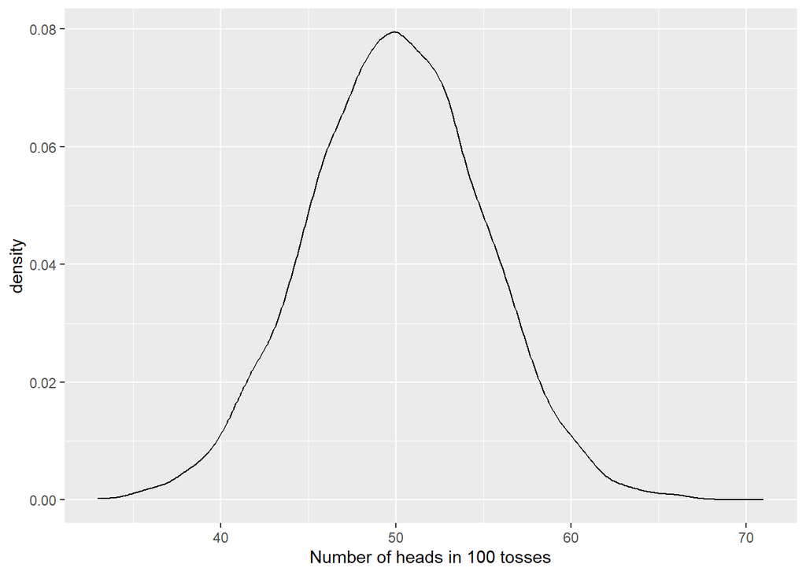

```r
T=10000
n=100
set.seed(11)
number_heads = vector()
for(i in 1:T){
outcomes = sample(c('Heads','Tails'), n, replace=T)
number_heads[i] = sum(outcomes=="Heads")
}

df = data.frame(number_heads)
View(df)

library(ggplot2)

ggplot(data = df) +
  geom_density(aes(x = number_heads)) +
  labs(x = "Number of heads in 100 tosses")
```

```r
summary(df$number_heads)
```

```
##    Min. 1st Qu.  Median    Mean 3rd Qu.    Max.
##   33.00   47.00   50.00   49.99   53.00   71.00
```

## One sample T test

### (p-value is greater than our alpha level of 0.05, we fail to reject the null hypothesis. We do not quite have sufficient evidence to say the mean is different from 178,000.)

```r
t.test(ames$Sale_Price, mu = 178000)
```

```
##
##  One Sample t-test
##
## data:  ames$Sale_Price
## t = 1.8945, df = 2929, p-value = 0.05825
## alternative hypothesis: true mean is not equal to 178000
## 95 percent confidence interval:
##  177902.3 183689.9
## sample estimates:
## mean of x
##  180796.1
```

### ttest with greater

```r
t.test(ames$Sale_Price, mu = 178000, alternative = 'greater')
```

```
##
##  One Sample t-test
##
## data:  ames$Sale_Price
## t = 1.8945, df = 2929, p-value = 0.02913
## alternative hypothesis: true mean is greater than 178000
## 95 percent confidence interval:
##  178367.7      Inf
## sample estimates:
## mean of x
##  180796.1
```

## 2 sample t test, diff of means btw 2 groups

####1_a.Testing normality( normality of sales for each value of central air*************)

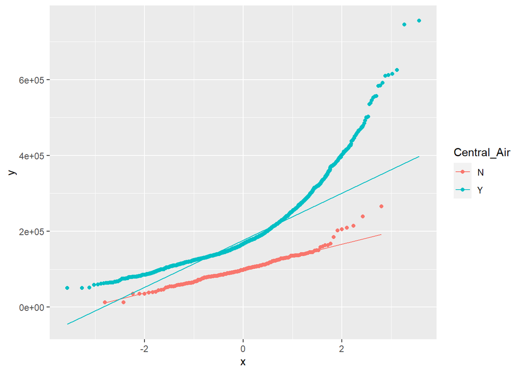

```r
ggplot(data = ames, aes(sample = Sale_Price, color = Central_Air)) +
     stat_qq() +
     stat_qq_line()
```

####1_b.Testing normality( null is normality, as P value is lower its not normal)

```r
shapiro.test(ames$Sale_Price[ames$Central_Air=='Y'])
```

```
##
##  Shapiro-Wilk normality test
##
## data:  ames$Sale_Price[ames$Central_Air == "Y"]
## W = 0.86295, p-value < 2.2e-16
```

```r
shapiro.test(ames$Sale_Price[ames$Central_Air=='N'])
```

```
##
##  Shapiro-Wilk normality test
##
## data:  ames$Sale_Price[ames$Central_Air == "N"]
## W = 0.95315, p-value = 4.739e-06
```

####2 Equality of variance( null is Var are equal, rejecting null so go for var.equal=FALSE in t test)

```r
var.test(Sale_Price ~ Central_Air, data = ames)
```

```
##
##  F test to compare two variances
##
## data:  Sale_Price by Central_Air
## F = 0.2258, num df = 195, denom df = 2733, p-value < 2.2e-16
## alternative hypothesis: true ratio of variances is not equal to 1
## 95 percent confidence interval:
##  0.1854873 0.2800271
## sample estimates:
## ratio of variances
##          0.2257977
```

### t test - 2 sample( null is means are equal), Our final conclusion from the t-test is the rejection of the null hypothesis and the conclusion that houses with and without central air should be expected to sell for different prices.

```r
  t.test(Sale_Price ~ Central_Air, data = ames, var.equal = FALSE)
```

```
##
##  Welch Two Sample t-test
##
## data:  Sale_Price by Central_Air
## t = -27.433, df = 336.06, p-value < 2.2e-16
## alternative hypothesis: true difference in means between group N and group Y is not equal to 0
## 95 percent confidence interval:
##  -90625.69 -78498.92
## sample estimates:
## mean in group N mean in group Y
##        101890.5        186452.8
```

##Mann-Whitney-Wilcoxon Test( when not normal) ### the distribution of Sale_Price was not precisely normal. The most principled way to proceed in this case would be with a non-parametric test :null the medians of the two groups are equal #### we make the same conclusion with our non-parametric test. Houses with and without central air should be expected to sell for different prices.

```r
wilcox.test(Sale_Price ~ Central_Air, data = ames)
```

```
##
##  Wilcoxon rank sum test with continuity correction
##
## data:  Sale_Price by Central_Air
## W = 63164, p-value < 2.2e-16
## alternative hypothesis: true location shift is not equal to 0
```